# Data

Spring 2026

## Data and Cleaning

Dataset: IPUMS Time Use

- Collection of time diary data
- American Heritage Time Use Study Extract Builder
- From 1930 to 2018, harmonized for comparison over time

Filters:

- Day: M-F
- Household type: married with kids
- Kids under 18 in household
- Working-age individuals (25 through 54)
- College educated
- Filter out missing/dirty values (wage, sex, time use)
- Year: 2010s

Transformations:

- Convert categorical variables to factors
- Convert time use variables to hours per day
- Combine time spent on child care and domestic work into one “unpaid domestic work” variable

| Variable | Description | Type |
| --- | --- | --- |
| WAGELM | Monthly employment income | Numerical |
| SEX | Individual's sex (female=1, male=0) | Binary |
| YEAR | Year of the diary entry | Numerical |
| HHID | Household type (1=married with child) | Categorical |
| UNDER18 | Number of children under 18 in the household | Numerical |
| AGEYNGST | Age of youngest child | Numerical |
| EDUC | Education (5=college graduate, 6=post college) | Categorical |
| AGE | Age of participant | Numerical |
| ACT_WORK | Daily time spent on paid work | Numerical |
| ACT_UNPAID | Daily time spent on unpaid domestic work | Numerical |
| ACT_CHCARE | Daily time spent on child care | Numerical |
| ACT_CIVIC | Daily time spent on civic, voluntary, and religious activities | Numerical |
| ACT_EDUCA | Daily time spent on education | Numerical |
| ACT_LEISURE | Daily time spent on free time (leisure) | Numerical |
| ACT_PCARE | Daily time spent on personal care | Numerical |
| ACT_TRAVEL | Daily time spent on travel | Numerical |

## EDA

### Unpaid Domestic Work by Sex

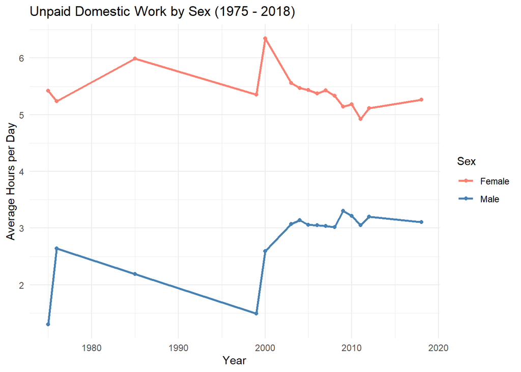

### Average Daily Time Use by Sex

This visualization breaks down the 24 hours in a day into the proportion of time spent on various activities, averaged across the 2010s. We see that on average, men spend more time on paid work than unpaid domestic work while women spend less time on paid work and more time on unpaid domestic work.

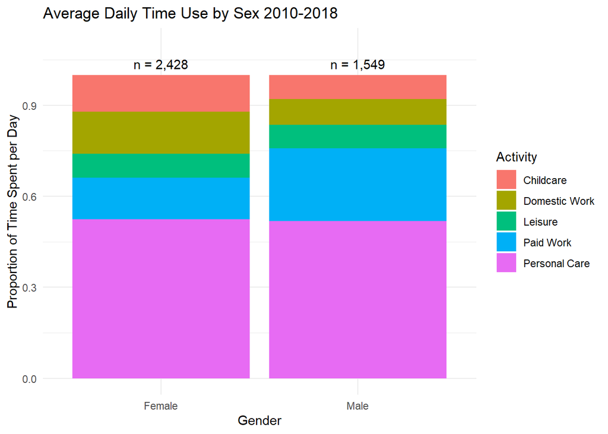

### Clustering in PCA Space

This visualization uses hierarchical clustering to find groupings in PCA space.

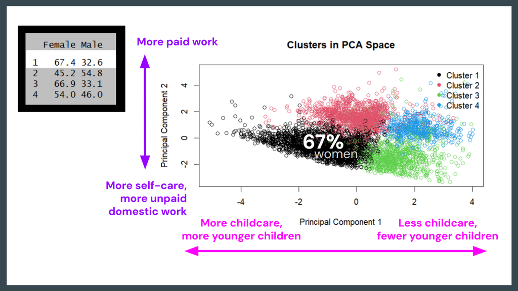

The first four PCs are defined below. Each PC represents a linear combination of variables that capture the most variation across individuals in this sample (** = most influential).

|  | PC1 | PC2 | PC3 | PC4 |
| --- | --- | --- | --- | --- |
| ACT_WORK | -0.257 | **-0.616** | -0.305 | -0.073 |
| ACT_CHCARE | **0.472** | 0.048 | -0.09 | -0.112 |
| ACT_EDUCA | -0.034 | -0.014 | -0.013 | 0.076 |
| ACT_LEISURE | -0.019 | 0.036 | **0.593** | **0.396** |
| ACT_MEDIA | -0.048 | 0.331 | **-0.379** | -0.012 |
| ACT_TRAVEL | -0.144 | -0.196 | **0.515** | 0.021 |
| ACT_SELFCARE | 0.02 | **0.42** | -0.047 | 0.345 |
| ACT_UNDOM | 0.18 | **0.407** | 0.054 | -0.298 |
| ACT_CIVIC | -0.035 | 0.118 | 0.302 | **-0.386** |
| AGEYNGST | **-0.558** | 0.225 | 0.017 | -0.229 |
| UNDER5 | **0.566** | -0.238 | 0.022 | 0.077 |
| UNDER18 | 0.145 | -0.074 | 0.205 | **-0.635** |

**PCA 1:** Time spent on childcare, age of youngest child, and amount of children under 5

**PCA 2:** Time spent at work, time spent on self care, and time spent on unpaid domestic work

Helped us hone in on variables of interest.